# Luangwa Lion Integrated Population Model

Survival, reproduction and population dynamics inside and outside South Luangwa National Park

Published

August 28, 2026

Generated from `output/ipm_samples_stoch`.RDS`. 3 chains × 60,000 iterations, burn-in 20,000, thin 10.

# 1 The model

This IPM follows Creel et al. (2024, *Conservation Science and Practice*), fitted to 590 individually identified lions monitored in and around South Luangwa National Park from 2008 to 2023.

Table 1: The four component models and the data each one uses.

Model structure

All components share one likelihood

| Component | Data | Estimates |
| --- | --- | --- |
| Cormack–Jolly–Seber | 590 capture histories over 64 occasions | Apparent survival by age class, sex and protection |
| Zero-inflated Poisson | 331 adult-female-years of cub counts | Fecundity by protection level |
| Leslie projection | — | Age structure, dispersal between strata, abundance through time |
| Gaussian state-space + process error | 11 annual closed-capture estimates | Population size as a latent variable; growth rate; observation error separated from real fluctuation |

**Occasions.** Four 2-month bins per year (May–Jun, Jul–Aug, Sep–Oct, Nov–Dec) give 64 occasions across 16 years. Creel et al. used three bins covering May–Oct; the Luangwa season runs later, and the fourth bin raises retention from roughly 75% to 90% of individual-months.

Survival is estimated on the **annual** scale, and the per-interval value the CJS needs is derived from it. That ordering matters twice over. The intervals are not equal — the gaps between bin midpoints run 0.167, 0.170, 0.167, 0.496 of a year, the last spanning the wet season — so treating each as a quarter of a year, as the published model does, overstates survival across the long gap and understates it across the three short ones. And a year random effect placed on per-interval survival is not identifiable, because per-interval survival sits close to 1 where the likelihood is flat; on the annual scale it is.

**Protection.** Every sighting was overlaid on the WDPA park boundary, and each lion classified by the majority of **all its sightings in a year**, applied to every occasion in that year. An occasion-level majority was tried first, but 44.9% of those classifications rested on a single sighting against 25.4% at the annual level, so one opportunistic excursion outside the boundary could define a whole 2-month bin and then propagate through carry-forward. Ties are broken by a coin flip, which makes the assignment mildly seed-dependent.

126 of 590 lions changed protected status during the study, which is what separates the protection effect from fixed differences between locations. The change of rule moved 5.5% of lion-occasions but left every estimate essentially untouched — `beta.prot` shifted by 0.027, a fifth of its posterior SD.

**Fecundity** is first-year cubs per adult female per year. Litter counts and sizes are observed; maternal identity was known for only a third of litters, so litters were allocated within their pride — named mothers first, the remainder at random among the other adult females, one each.

**Movement.** The projection is not a pair of closed sub-populations. Lions move between strata constantly, and the model estimates annual transition rates from lion-years where the stratum was observed in both year *t* and *t+1*, then moves survivors accordingly. This matters more than it might appear — see Section 7.2.

Table 2: Movement between strata. The model estimates the transition rates; the observed column is the raw count from the capture histories and is not fitted to directly, so the agreement is a check rather than a tautology.

Dispersal between strata

Estimated inside the IPM, against the raw capture-history counts

| Quantity | Estimate | 95% CrI | Observed |
| --- | --- | --- | --- |
| Annual P(move outside \| inside) | 0.085 | 0.073 – 0.098 | 0.079 |
| Annual P(move inside \| outside) | 0.292 | 0.247 – 0.341 | 0.309 |
| Equilibrium proportion inside | 0.774 | 0.744 – 0.801 | 0.796 |

Rates apply to all ages and both sexes. Cubs move with their pride rather than dispersing independently, so a shared rate is reasonable for them; treating male and female dispersal as equal is a simplification worth relaxing.

# 2 Headline results

Table 3: Headline estimates. Intervals are 95% credible intervals.

Headline estimates

| Quantity | Estimate | 95% CrI |
| --- | --- | --- |
| Effect of being outside the park on logit(survival) | <sup>1</sup> −0.570 | −0.832 – −0.312 |
| Effect of being male on logit(survival) | <sup>1</sup> −0.771 | −0.997 – −0.542 |
| Fecundity, inside park (cubs / adult female / year) | 0.479 | 0.369 – 0.609 |
| Fecundity, outside park | 0.550 | 0.352 – 0.832 |
| Population size, 2023 | 202.432 | 168.704 – 228.447 |
| Population growth rate, 2022–2023 | 0.928 | 0.811 – 1.065 |

<sup>1</sup> Credible interval excludes zero.

Lions ranging outside the park have substantially lower apparent survival. Creel et al. found only a weak tendency in the same direction in Kafue. Protected status shows no effect on fecundity.

Apparent survival is modeled here, which may confound mortality with permanent emigration. Lions ranging outside the park are plausibly may also be more likely to leave the study area altogether, so part of the protection effect may be dispersal rather than death?

# 3 Survival

Table 4: Annual apparent survival by age class, sex and protection stratum.

Annual apparent survival

Posterior median (95% credible interval)

| Age class | Inside park Female | Inside park Male | Outside park Female | Outside park Male |
| --- | --- | --- | --- | --- |
| Cub (0–1.99) | 0.808 (0.723–0.866) | 0.659 (0.547–0.747) | 0.702 (0.595–0.794) | 0.521 (0.397–0.640) |
| Subadult (2–3.99) | 0.879 (0.813–0.918) | 0.771 (0.669–0.835) | 0.803 (0.706–0.867) | 0.655 (0.526–0.749) |
| Prime (4–5.99) | 0.916 (0.863–0.946) | 0.834 (0.746–0.889) | 0.859 (0.781–0.910) | 0.738 (0.618–0.824) |
| Old (6+) | 0.857 (0.792–0.893) | 0.733 (0.630–0.799) | 0.770 (0.679–0.830) | 0.608 (0.483–0.704) |

The model estimates additive effects of sex and protection on the logit scale, with no interaction.

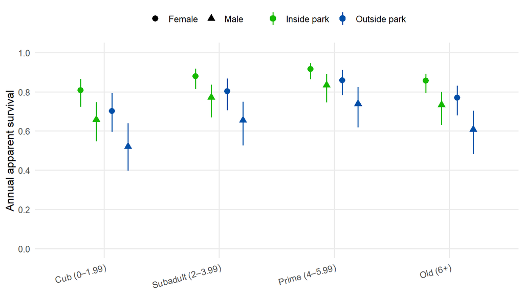

Figure 1: Annual apparent survival. Points are posterior medians, bars 95% credible intervals.

Survival rises from cub to prime adult and falls again in old age, in every sex-by-protection combination. The gap between strata is constant on the logit scale by construction: the model fits additive effects with no interaction, as in the published analysis.

# 4 Reproduction

Table 5: Fecundity component. The zero-inflated Poisson separates whether a female bred at all from how many cubs she raised.

Fecundity

First-year cubs per adult female per year

|  | Median | 95% CrI | Rhat |
| --- | --- | --- | --- |
| log mean litter contribution, inside park (α) | 0.787 | 0.547 – 0.977 | 1.016 |
| Probability a female bred (ψ) | 0.217 | 0.175 – 0.266 | 1.009 |
| Difference for outside park, log scale (γ₂) | 0.138 | −0.303 – 0.568 | 1.007 |
| Fecundity, inside park | 0.479 | 0.369 – 0.609 | 1.006 |
| Fecundity, outside park | 0.550 | 0.352 – 0.832 | 1.004 |

Based on 331 adult-female-years, 2008–2015. Maternal identity was imputed within pride-years for the litters where it was unknown.

Only about 22% of adult-female-years involved breeding (the zero inflation doing its job) — a lioness with surviving cubs from the previous year does not conceive. Among those that did breed, the Poisson mean was 2.19 cubs.

# 5 Posterior distributions

Laid out as in Figure 3 of Creel et al.: fecundity on top, then annual apparent survival for each age class, with both sexes and both strata overlaid. Showing the full posterior rather than an interval makes the degree of overlap between strata visible — which is the quantity of interest when asking whether protection matters.

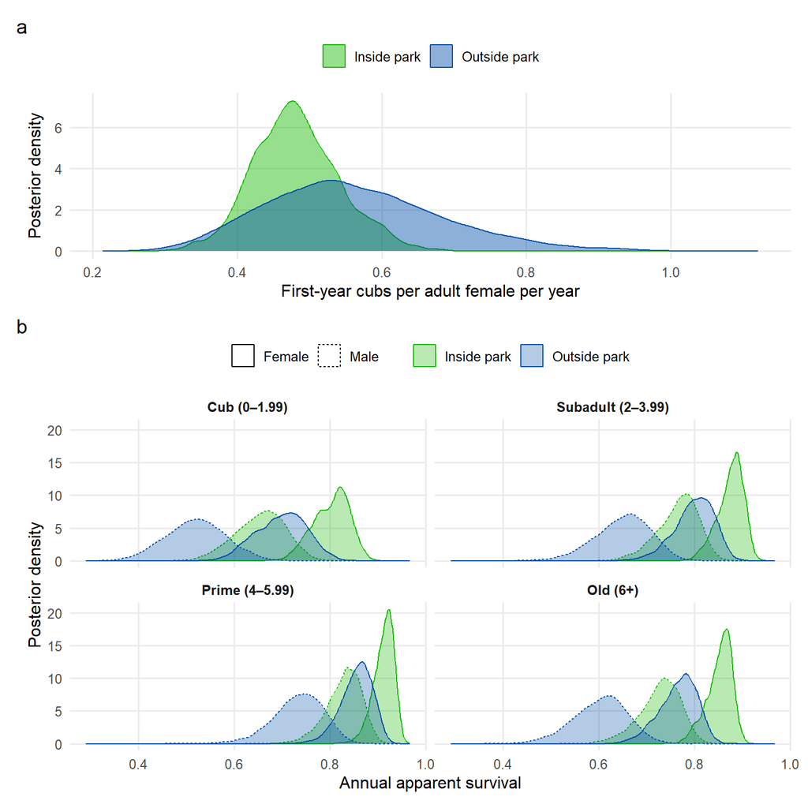

Figure 2: Posterior distributions by protection level. (a) Adult female fecundity, as first-year cubs per female. (b) Annual apparent survival for the four age classes; within each panel the male distributions sit to the left of the female ones.

The separation between strata is consistent across all four age classes, because the model fits an additive protection effect on the logit scale with no age interaction — the panels show how that constant shift translates into different absolute gaps at different baseline survival rates. Fecundity, by contrast, shows two distributions that overlap almost entirely.

# 6 Between-year variation

Survival and fecundity each carry a year random effect, on the annual logit and log scales respectively. Both are shrunk toward zero by the data rather than imposed.

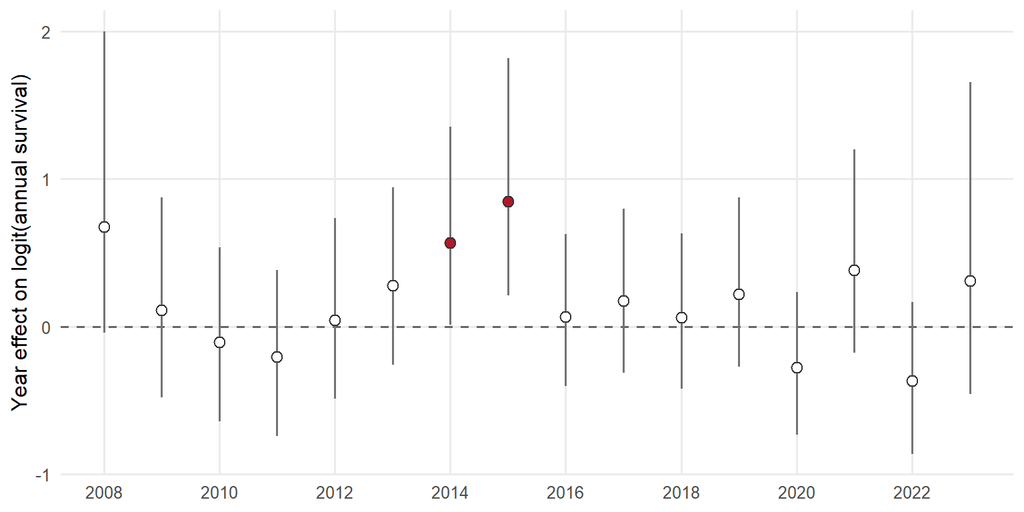

Figure 3: Year random effect on annual survival, on the logit scale. Points are posterior medians, bars 95% credible intervals; a year whose interval clears zero is filled.

Table 6: Variance components. sigma.yr and sigma.fec.yr are the between-year SDs of survival and fecundity on their respective link scales.

Variance components

|  | Median | 95% CrI | Rhat | n.eff |
| --- | --- | --- | --- | --- |
| Between-individual SD, detection (logit) | 1.208 | 1.080 – 1.355 | 1.000 | 4,357 |
| Sampling SD, population estimates | 16.979 | 1.432 – 41.485 | 1.001 | 1,643 |
| Between-year SD, survival (logit) | 0.501 | 0.235 – 1.066 | 1.009 | 302 |
| Between-year SD, fecundity (log) | 0.081 | 0.005 – 0.337 | 1.035 | 284 |

`sigma.yr` is 0.501 (0.235 – 1.066). For a prime adult female inside the park, mean annual survival of 0.916 and a ±1 SD year effect span roughly 0.87 to 0.95. Only 2014, 2015 has a year effect whose interval clears zero.

**This effect is only estimable on the annual scale.** Placed on per-interval survival — the natural way to write it, since that is what the CJS models — `sigma.yr` is not identified at all. Per-interval survival is about 0.96, which on the logit scale sits close enough to the boundary that large changes barely move the probability; the likelihood is flat there and `sigma.yr` runs to whatever bound the prior supplies. Widening the prior from `dunif(0,5)` to `dunif(0,20)` moved the estimate from 3.9 to 15.9, which is how this was diagnosed. On the annual scale, where survival is around 0.85, it is well identified and R̂ = 1.009.

`sigma.fec.yr` = 0.081 (0.005 – 0.337) is shrunk hard toward zero. With 331 female-years across 8 years and 79% of them zeros, between-year variation cannot be separated from the zero-inflation parameter ψ. Read that as *not detectable in these data*, not as evidence that fecundity is constant.

# 7 Population size and growth

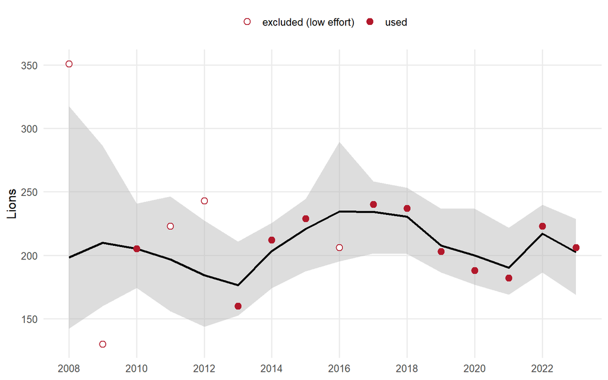

Figure 4: Population size from the IPM against the closed-capture estimates it was fitted to. Open points are years excluded by the survey-effort restriction and contribute no likelihood.

Table 7: Population size by year, with the closed-capture estimate supplied to the state-space model.

Population size

IPM posterior against the closed-capture input

| Year | Closed capture | Used | IPM median | 95% CrI | per 100 km² |
| --- | --- | --- | --- | --- | --- |
| 2008 | 351 |  | 198 | 142 – 318 | 4.96 |
| 2009 | 130 |  | 210 | 160 – 286 | 5.25 |
| 2010 | 205 | ✓ | 205 | 174 – 241 | 5.13 |
| 2011 | 223 |  | 197 | 156 – 246 | 4.92 |
| 2012 | 243 |  | 184 | 144 – 227 | 4.60 |
| 2013 | 160 | ✓ | 176 | 152 – 211 | 4.41 |
| 2014 | 212 | ✓ | 203 | 174 – 225 | 5.08 |
| 2015 | 229 | ✓ | 221 | 188 – 245 | 5.52 |
| 2016 | 206 |  | 235 | 195 – 290 | 5.87 |
| 2017 | 240 | ✓ | 234 | 202 – 258 | 5.85 |
| 2018 | 237 | ✓ | 230 | 201 – 253 | 5.76 |
| 2019 | 203 | ✓ | 208 | 186 – 237 | 5.19 |
| 2020 | 188 | ✓ | 200 | 177 – 237 | 4.99 |
| 2021 | 182 | ✓ | 190 | 169 – 222 | 4.75 |
| 2022 | 223 | ✓ | 217 | 186 – 240 | 5.42 |
| 2023 | 206 | ✓ | 202 | 169 – 228 | 5.06 |

Density uses a placeholder area of 4,000 km². Replace AREA_KM2 in R/04_ipm.R with the kernel-utilisation estimate before reporting density.

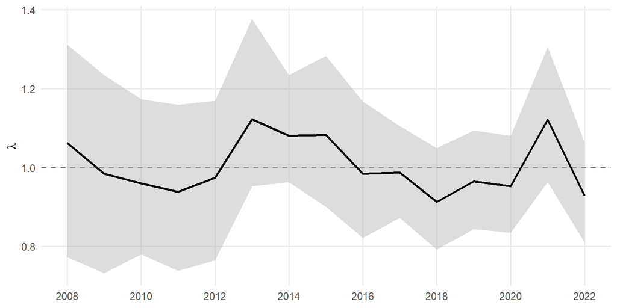

Figure 5: Annual population growth rate. Survival carries a year random effect that feeds through into the projection, so this varies with the estimated year-to-year survival rather than being constant. Fecundity is held at its marginal mean – see the note below.

**What this variation does and does not include.** $\lambda$ varies here because the year random effect on survival feeds through into the projection. It tracks that effect closely — the correlation between $\lambda$ and `eps.yr` is 0.99 — so this is year-to-year variation in growth attributable to *measured survival*.

The projection also carries process error, so variation beyond what survival explains has somewhere to go rather than being charged to observation error. What remains outside the model is attribution: `sigma.proc` is a flat multiplier on abundance and cannot say which vital rate moved. Fecundity is still held at its marginal mean across years, because the litter records stop in 2015 and a year-specific value for 2016-2023 would come from the prior rather than from data, so recruitment variation lands in `sigma.proc` undifferentiated.

## 7.1 Splitting observation error from real fluctuation

Without process error every departure of the population from the fitted trajectory is charged to `sigma.c`, which conflates two different things: how imprecise the closed-capture estimates are, and how much the population actually fluctuates. Fitting both separates them.

Variance decomposition

At a mean population of 207 lions

| Source | Parameter | Estimate | 95% CrI | As lions |
| --- | --- | --- | --- | --- |
| Observation error in the closed-capture estimates | sigma.c | 16.979 | 1.432 – 41.485 | 17.0 |
| Process error: real year-to-year fluctuation | sigma.proc | 0.090 | 0.004 – 0.222 | 19.4 |

sigma.c is already in lions; sigma.proc is an SD on the log scale, shown as the equivalent proportional swing at the mean population size.

The two are comparable in size – roughly 17 lions of measurement imprecision against 19 lions of genuine fluctuation, a 9.4% annual CV. Fitted without process error the same model puts `sigma.c` at 25.0, so about a third of what was being called observation error is really the population moving.

Two cautions. The lower bound on `sigma.proc` is 0.004, so the data do not exclude near-zero process variance. And `sigma.c` spans 1.4 to 41.5: with 11 population estimates the split between the two is informed but not sharply determined.

Laid out as in Figure 4 of Creel et al.: the growth-rate posterior, then the density trend with credible intervals. Panel (a) covers the population as a whole; Section 7.2 explains why that is the right unit here.

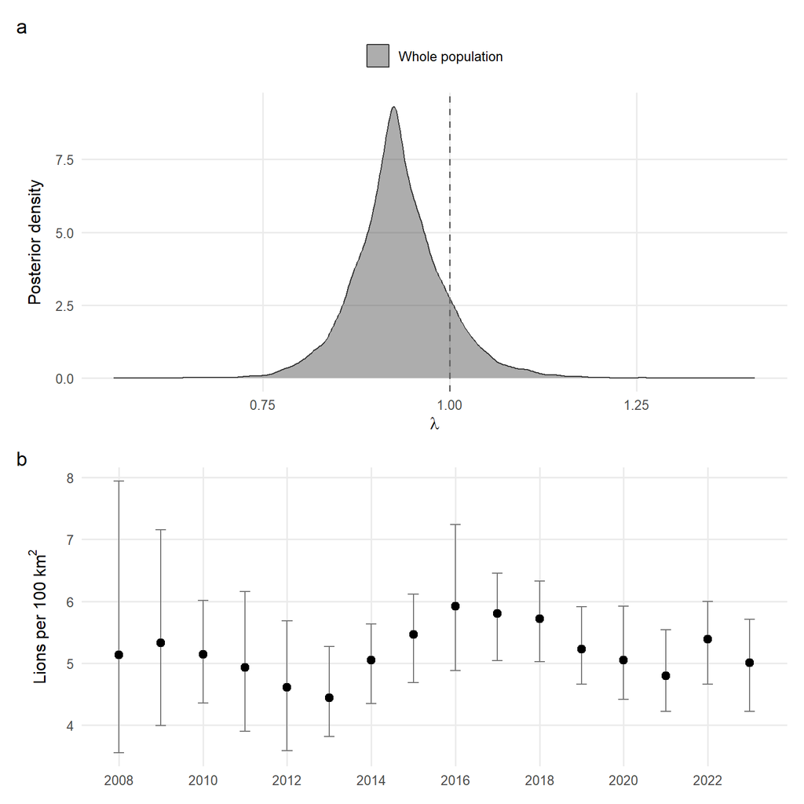

## 7.2 Why one growth rate and not two

Creel et al.’s Figure 4a shows λ separately for high and low protection. This model reports a single λ — not because the split could not be estimated, but because the model with dispersal shows there is no split to report.

Table 8: Stratum-specific growth rates in the final year. These are separate parameters in the model, estimated independently, and they converge on the same value.

Growth rate by stratum

| Stratum | λ | 95% CrI | Rhat |
| --- | --- | --- | --- |
| Inside park | 0.9318 | 0.8156 – 1.0677 | 1.002 |
| Outside park | 0.9138 | 0.7907 – 1.0537 | 1.003 |
| Whole population | 0.9280 | 0.8107 – 1.0646 | 1.002 |

Table 9: Difference in growth rate between strata, year by year. Taken from the posterior of the difference rather than by comparing two marginal intervals, which would overstate the separation because the two are strongly correlated.

Growth rate, inside vs outside the park

|  | Inside | Outside | Difference | 95% CrI |
| --- | --- | --- | --- | --- |
| 2008–2009 | 1.0574 | 1.0806 | −0.0220 | −0.0672 – 0.0014 |
| 2009–2010 | 0.9851 | 0.9795 | 0.0043 | −0.0196 – 0.0290 |
| 2010–2011 | 0.9621 | 0.9518 | 0.0092 | −0.0122 – 0.0329 |
| 2011–2012 | 0.9406 | 0.9308 | 0.0091 | −0.0104 – 0.0308 |
| 2012–2013 | 0.9746 | 0.9762 | −0.0023 | −0.0277 – 0.0170 |
| 2013–2014 | 1.1203 | 1.1337 | −0.0105 | −0.0406 – 0.0102 |
| 2014–2015 | 1.0770 | 1.0942 | −0.0161 | −0.0437 – 0.0020 |
| 2015–2016 | 1.0796 | 1.0983 | −0.0181 | −0.0454 – −0.0003 |
| 2016–2017 | 0.9875 | 0.9736 | 0.0127 | −0.0031 – 0.0346 |
| 2017–2018 | 0.9885 | 0.9845 | 0.0038 | −0.0131 – 0.0221 |
| 2018–2019 | 0.9149 | 0.9063 | 0.0061 | −0.0089 – 0.0242 |
| 2019–2020 | 0.9649 | 0.9642 | −0.0008 | −0.0195 – 0.0157 |
| 2020–2021 | 0.9558 | 0.9396 | 0.0158 | 0.0004 – 0.0373 |
| 2021–2022 | 1.1180 | 1.1360 | −0.0141 | −0.0432 – 0.0060 |
| 2022–2023 | 0.9318 | 0.9138 | 0.0172 | −0.0003 – 0.0405 |

The two series correlate 0.9964. The difference excludes zero in 2 of 15 intervals.

The two strata track each other almost exactly: the series correlate 0.9964, the largest gap in any year is 0.023, and the difference excludes zero in **2 of 15 intervals**.

That is close to a structural necessity rather than a coincidence. Dispersal holds the composition near its equilibrium, and a population whose composition is stationary must grow at one rate throughout. Year-varying survival perturbs that slightly — under constant vital rates the two were identical to four decimal places — but never enough to separate them.

“Growth rate of the protected sub-population” is only a distinct quantity if the sub-populations are demographically closed, and with 126 of 590 lions changing stratum, these are not.

**How this was established.** Fitted without dispersal, the stratum-specific quantities were unidentified: `Pop[t]` observes only the total, and `Nprot` and `lambda.prot` returned $\hat{R}$ up to 1.26 with effective sample sizes near 12. Adding composition data alone made things worse — with no dispersal available the model matched the observed composition by distorting the vital rates instead, pushing `beta.prot` to −1.1 and `sigma.c` to ~70.

Adding dispersal fixed both. Vital rates are unchanged from the no-composition fit (`beta.prot` −0.542 → −0.518, `sigma.c` 29.9 → 29.3), and non-converged parameters went from 47 of 156 to **0 of 175**. The equality of the two λ values is therefore a converged result, not a symptom of poor mixing.

Density in panel (b) uses the placeholder area of 4,000 km². Only the vertical scale depends on it; the shape of the trend and the relative widths of the intervals do not.

# 8 Data behind the model

Table 10: Closed-capture model by year. Years were excluded where survey effort was too low, the chain did not converge, or the posterior pressed against the data-augmentation ceiling.

Annual closed-capture estimates

Model Mh with data augmentation, monthly occasions

| Year | Identified | Detections / lion | N | 95% CrI | p | σ | R̂ | Used |
| --- | --- | --- | --- | --- | --- | --- | --- | --- |
| 2008 | 84 | 1.48 | 351 | 217 – 417 | 0.02 | 1.45 | 1.02 |  |
| 2009 | 99 | 2.27 | 130 | 111 – 187 | 0.18 | 0.86 | 1.05 |  |
| 2010 | 100 | 2.70 | 205 | 141 – 340 | 0.08 | 2.04 | 1.01 | ✓ |
| 2011 | 120 | 2.29 | 223 | 164 – 430 | 0.09 | 1.53 | 1.04 |  |
| 2012 | 91 | 1.99 | 243 | 140 – 429 | 0.05 | 1.66 | 1.02 |  |
| 2013 | 121 | 2.90 | 160 | 138 – 213 | 0.21 | 1.34 | 1.00 | ✓ |
| 2014 | 169 | 3.66 | 212 | 188 – 263 | 0.30 | 1.67 | 1.01 | ✓ |
| 2015 | 156 | 2.85 | 229 | 190 – 300 | 0.17 | 1.53 | 1.01 | ✓ |
| 2016 | 172 | 2.23 | 206 | 186 – 248 | 0.22 | 0.52 | 1.32 |  |
| 2017 | 196 | 3.80 | 240 | 217 – 281 | 0.33 | 1.66 | 1.00 | ✓ |
| 2018 | 198 | 3.40 | 237 | 216 – 274 | 0.31 | 1.36 | 1.01 | ✓ |
| 2019 | 183 | 3.21 | 203 | 191 – 222 | 0.34 | 0.89 | 1.01 | ✓ |
| 2020 | 166 | 3.20 | 188 | 174 – 212 | 0.32 | 0.98 | 1.02 | ✓ |
| 2021 | 123 | 2.54 | 182 | 147 – 269 | 0.15 | 1.32 | 1.02 | ✓ |
| 2022 | 149 | 3.13 | 223 | 183 – 322 | 0.17 | 1.81 | 1.04 | ✓ |
| 2023 | 133 | 2.62 | 206 | 163 – 302 | 0.14 | 1.48 | 1.03 | ✓ |

Detections per identified lion is the effort measure the restriction is based on. It runs from 1.5 to 3.8, and correlates -0.73 with how far the closed-capture estimate exceeds the number of lions actually identified. In other words, thinly surveyed years produce inflated abundance estimates, because an Mh model explains “each lion seen fewer times” by positing more lions it never saw. With no independent effort covariate available, the only honest response was to drop those years.

# 9 Convergence

Table 11: Convergence summary across all monitored parameters.

MCMC diagnostics

| Diagnostic | Value |
| --- | --- |
| Monitored parameters | 1241 |
| Maximum R̂ | 1.0352 |
| Parameters with R̂ > 1.1 | 0 |
| Minimum effective sample size | 154 |
| Median effective sample size | 2,069 |

# 10 Caveats

1. **Apparent survival is not true survival.** Permanent emigration is indistinguishable from death in a CJS model, and it is plausibly more common outside the park, where the protection effect is measured.
2. **Cub survival is high** relative to published lion estimates because cubs enter the data only once individually identified, so mortality in the first months of life is invisible.
3. **Fecundity rests on imputed maternity** and covers 2008–2015, while survival covers 2008–2023. It is estimated as one rate per stratum rather than per year, so the mismatch is survivable, but this is the weakest input in the model, and the absent protection effect on fecundity may reflect the imputation as much as the biology.
4. **Population size rests on 11 of 16 years.**
5. **Density is provisional** until `AREA_KM2` is replaced with a real estimate of the area occupied.
6. **This model departs from the published Kafue code in five documented ways**, three of which change $\lambda$. See the header of `R/04_ipm.R`. Estimates here are not directly comparable with the published figures.